# Assignment_9

mitchell

2023-11-13

## R Markdown_GradSchool_Admissions

The following data analysis examines the acceptance rates of graduate school applicants. This analysis will help students visualize and predict which rank of school they are likely to be accepted to based on their GRE scores and GPA. I have used R markdown to present my data analysis in an HTML format.

Data summary

| Name | GradData |
| --- | --- |
| Number of rows | 400 |
| Number of columns | 4 |
| _______________________ |  |
| Column type frequency: |  |
| numeric | 4 |
| ________________________ |  |
| Group variables | None |

**Variable type: numeric**

| skim_variable | n_missing | complete_rate | mean | sd | p0 | p25 | p50 | p75 | p100 | hist |
| --- | --- | --- | --- | --- | --- | --- | --- | --- | --- | --- |
| admit | 0 | 1 | 0.32 | 0.47 | 0.00 | 0.00 | 0.0 | 1.00 | 1 | ▇▁▁▁▃ |
| gre | 0 | 1 | 587.70 | 115.52 | 220.00 | 520.00 | 580.0 | 660.00 | 800 | ▁▂▇▇▅ |
| gpa | 0 | 1 | 3.39 | 0.38 | 2.26 | 3.13 | 3.4 | 3.67 | 4 | ▁▃▆▇▆ |
| rank | 0 | 1 | 2.48 | 0.94 | 1.00 | 2.00 | 2.0 | 3.00 | 4 | ▃▇▁▆▃ |

The source data has 4 variables and 400 observations. The four variables include Admitance,gre,gpa,rank.

## The story told in Plots

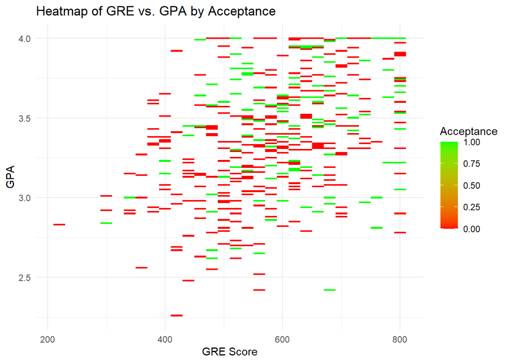

## Bar chart for “admitance” which is a binary outcome

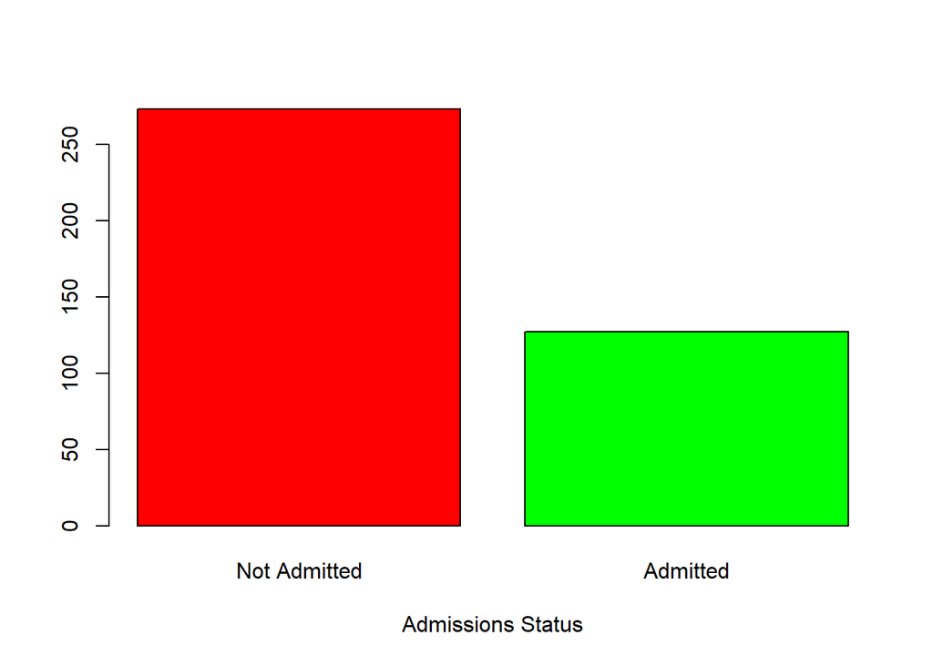

## Histograms for GRE Scores and GPA, which are numerical predictors

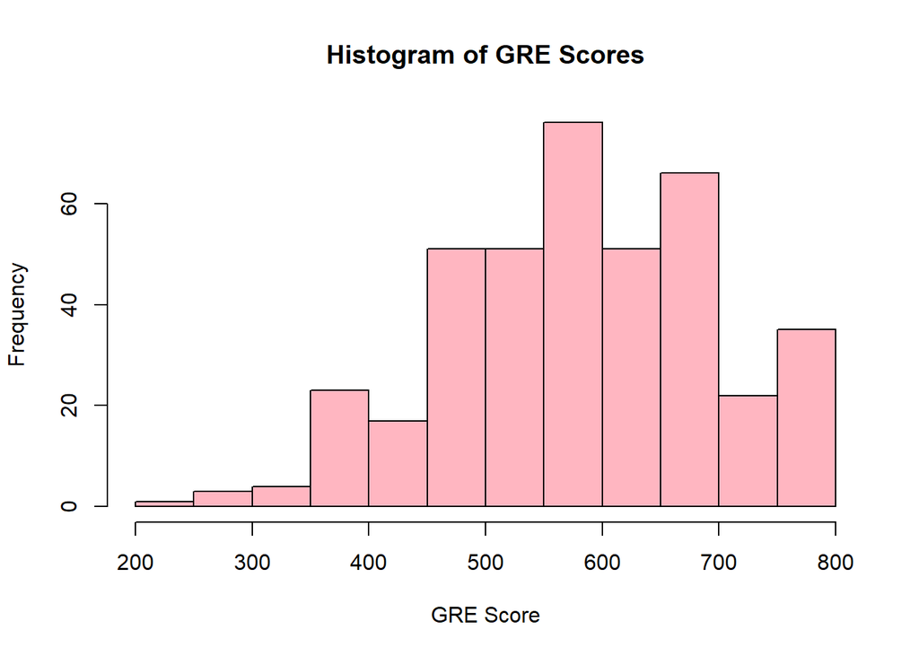

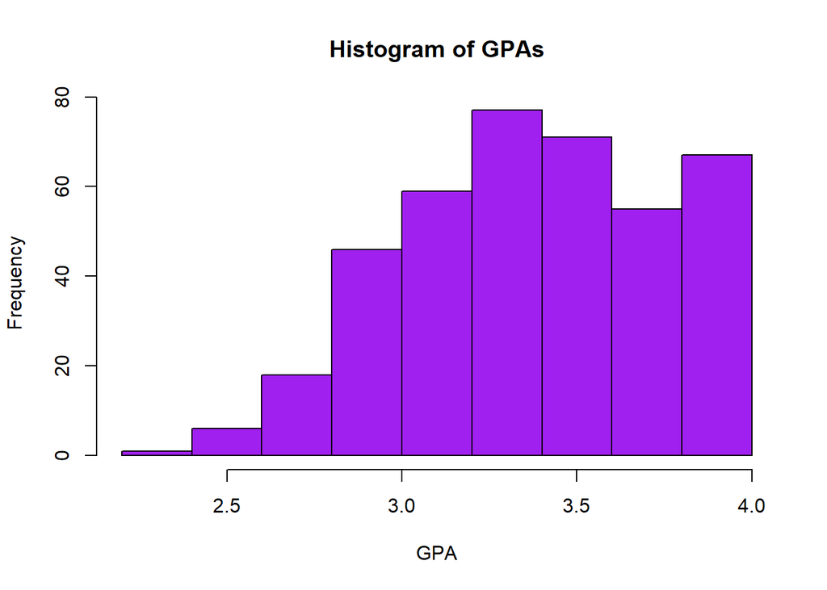

## Box plot to visualize the relationship between GRE scores and admission

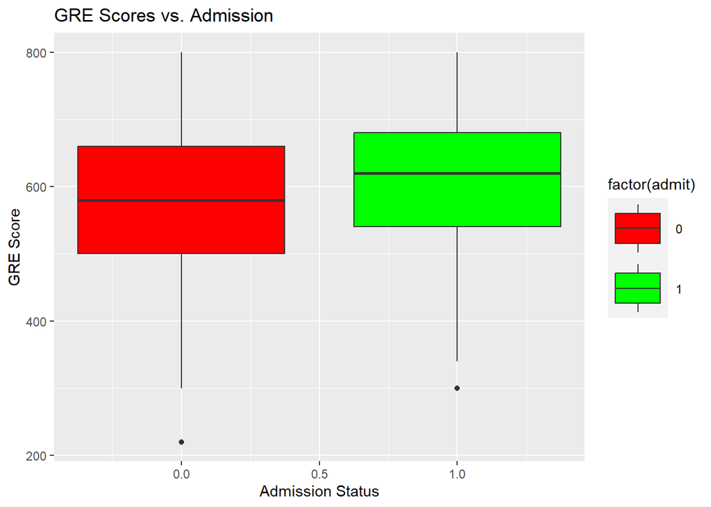

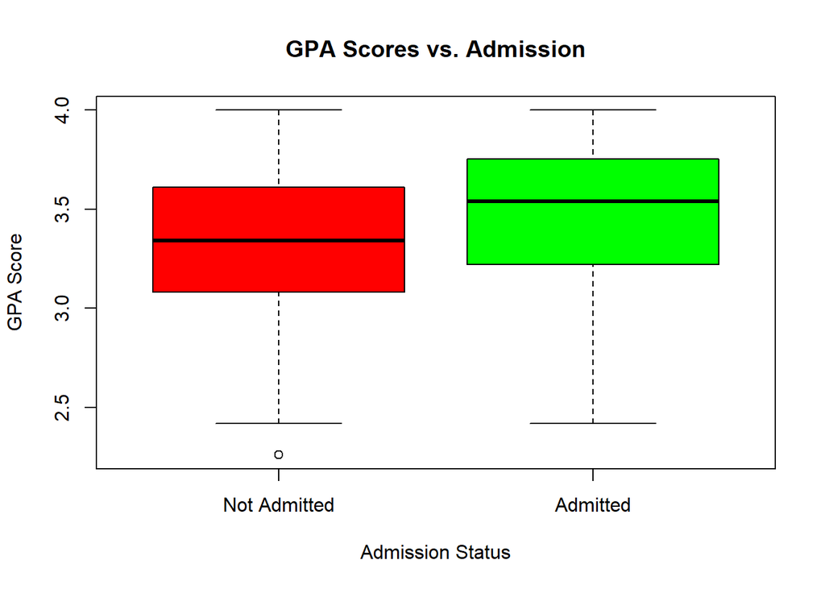